# Chapter 2: The AMMonitor Database

# Chapter Introduction

The primary goal of **AMMonitor** is to provide a system that efficiently processes remotely captured data so that agencies or organizations tasked with managing natural resources can easily compare the current state of the ecosystem (e.g., species occupancy patterns) to management objectives. Autonomous Monitoring Units (AMUs) have the capacity to collect a massive amount of information in a short period of time, requiring that monitoring teams have an effective data management plan in place.

In the **AMMonitor** system, raw monitoring files such as recordings and photos are stored in the Dropbox Cloud (intentionally not synced to a user’s computer). All other data, including photo and recording metadata, are stored within a [SQLite database](https://www.sqlite.org/index.html). SQLite is a self-contained, high-reliability, embedded, full-featured, public-domain, SQL database engine. **AMMonitor** uses the R package RSQLite [1] to connect R with the database.

SQLite is a **relational database**, which is simply a collection of tables that are related in some way. Each table stores specific information, and specific columns in one table may be formally linked to other tables. Information stored in or across tables can be retrieved using a language called SQL, which stands for Structured Query Language. You will learn some basic SQL commands in this chapter, but much of your work will done in R.

Typically, SQL databases are stored on a large server (such as the server at a university or agency) that requires management and oversight by a database administrator. In contrast, a SQLite database does not require a server or administrator. Instead, the entire database is stored as a single file, which may reside on a single computer or in the cloud. The SQLite home page explains: “SQLite is an in-process library that implements a self-contained, serverless, zero-configuration, transactional SQL database engine. The code for SQLite is in the public domain and is thus free for use for any purpose, commercial or private. SQLite is the most widely deployed database in the world with more applications than we can count, including several high-profile projects.” [2]

An **AMMonitor** SQLite database is created with the `dbCreate()` function, and should be stored in the “database” folder within the main AMMonitor directory.

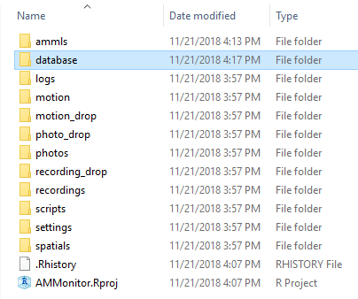

> *Figure 2.1. The “database” directory should store the AMMonitor SQLite database file.*

Before we actually create the database, we provide an overview of the tables within an **AMMonitor** database.

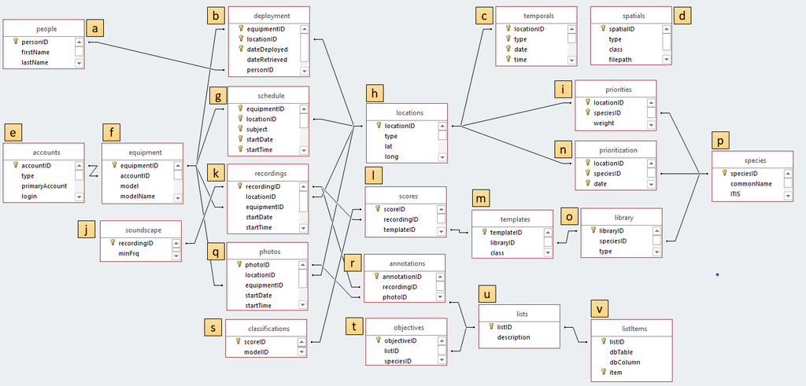

> *Figure 2.2. AMMonitor database schema, showing key tables with a few columns. Lines between tables indicate how tables are related to each other.*

If you are new to relational databases, think of a database as several Excel worksheets (a workbook), where each sheet is a table that stores specific information. The tables are linked in a specific way.

Though Fig. 2.2 provides an overview of the **AMMonitor** database, we will introduce each table in depth in the coming chapters.

# Keys

### Foreign Keys

The concept of primary keys and foreign keys is essential to relational databases. Primary and foreign keys allow information to be distributed across tables so that the same information is never duplicated, and they help maintain the integrity of the data collected. We will examine the table relationships as a matter of practice in future chapters. For more information, view a [tutorial](https://www.tutorialspoint.com/sql/sql-rdbms-concepts.htm) on relational database concepts.

# Create the database

Creating the **AMMonitor** database is extremely simple. Here, users have two options:

1. Use the `dbCreate()` function to create a blank database. This is what users should do after reading or skimming through the entire book and are ready to launch a monitoring program. This function has two arguments: the ‘db.name’ (desired name of the database) and the ‘file.path’ (where to store this SQLite file). All tables and keys are generated automatically. Tables are empty, but fully equipped to intake new information.
2. Use the `dbCreateSample()` function to generate a sample database. This is the approach we will use throughout this book. `dbCreateSample()` generates all tables in an **AMMonitor** database, and, for demonstration purposes, pre-populates certain tables with sample data that comes with the package. This function has three arguments: the ‘db.name’, ‘file.path’, and ‘tables’ (the names of the database tables that should be filled with sample data; all other tables are present but empty).

For this chapter, we will use `dbCreateSample()` to generate a sample SQLite database named “Chap2.sqlite”. Below, we fill all tables with sample data by specifying ‘all’ for the tables argument.

```r
# Create a sample database for this chapter
dbCreateSample(db.name = "Chap2.sqlite",
               file.path = paste0(getwd(),"/database"),
               tables =  'all')
```

```
## An AMMonitor database has been created with the name Chap2.sqlite which consists of the following tables:
```

```
## accounts, annotations, assessments, classifications, deployment, equipment, library, listItems, lists, locations, logs, objectives, people, photos, priorities, prioritization, recordings, schedule, scores, scriptArgs, scripts, soundscape, spatials, species, sqlite_sequence, templates, temporals
```

```
##
## Sample data have been generated for the following tables:
## accounts, lists, people, species, spatials, scripts, equipment, locations, deployment, library, listItems, objectives, priorities, prioritization, recordings, photos, annotations, schedule, templates, scores, classifications, soundscape, temporals, scriptArgs, analysis, logs, assessments
```

Next, we connect to the database in R using RSQLite’s `dbConnect()` function, where we identify the SQLite driver in the ‘drv’ argument:

```r
# Establish the database file path as db.path
db.path <- paste0(getwd(), '/database/Chap2.sqlite')

# Connect to the database
conx <- RSQLite::dbConnect(drv = dbDriver('SQLite'), dbname = db.path)
```

Finally, we send a SQLite statement to enforce foreign key constraints:

```r
# Turn the SQLite foreign constraints on
RSQLite::dbExecute(conn = conx, statement =
              "PRAGMA foreign_keys = ON;"
          )
```

```
## [1] 0
```

This is our first look at SQLite syntax, passed through the `dbExecute()` ‘statement’ argument. The word PRAGMA (from “pragmatic”) is a computer programming directive that tells SQLite how to process input. Here, we are telling SQLite to enforce foreign key contraints. That means if a person named Gandalf deploys equipment, and we create a new record in the **deployment** table indicating so, Gandalf must be present in the **people** table, or an error will occur. This ensures the database stays tidy and clean.

Sending a SQLite statement with the `dbExecute()` function is one way to interact with the database. Another way is through **AMMonitor** functions. For example, throughout this vignette, we will be using the `dbTables()` function to view a particular table’s columns, the type of data it stores, and its primary keys. For example:

```r
# Look at the structure of the deployment table
dbTables(db.path = db.path, table = 'deployment')
```

```
## $deployment
##   cid          name         type notnull dflt_value pk comment
## 1   0   equipmentID VARCHAR(255)       1         NA  1
## 2   1    locationID VARCHAR(255)       1         NA  2
## 3   2  dateDeployed VARCHAR(255)       1         NA  3
## 4   3 dateRetrieved VARCHAR(255)       0         NA  0
## 5   4      personID VARCHAR(255)       0         NA  0
## 6   5         notes         TEXT       0         NA  0
```

Here, the output tells us about each of the columns (fields) in the **deployment** table. The field *cid* is simply the column identifier (automatically created). The field *name* gives the names of the table’s columns. Here, we see that the **deployment** table has columns named ‘equipmentID’, ‘locationID’, ‘dataDeployed’, and so on.

The field *type* tells what sort of data are stored in each column. These data types are different from R’s datatypes (e.g., character, number, integer, logical). Because this is a SQLite database, the character types must be recognized by SQLite. Here, notice that most columns are set to VARCHAR(255), which means the columns store characters that are variable in length (up to 255 characters). The ‘notes’ column stores TEXT, which can accommodate lengthy text entries. See https://www.sqlite.org/datatype3.html for more information on SQLite data types.

The field *notnull* indicates whether an entry is required for each column or not (1 = required; 0 = not required). You can see that the first three columns are all required. The field *dflt_value* provides the default value for each column, if specified.

Finally, the field *pk* identifies column(s) that make up the primary key. Every table must have a primary key. Here, the *equipmentID*, *locationID*, and *dateDeployed* columns combine to create the table’s primary key (a composite key).

We mentioned that the **deployment** table contains foreign keys, which means that some columns reference primary keys from other tables. In fact, the **deployment** table’s primary key consists of two foreign keys. We can send a **query** to the SQLite database, and request the foreign key information for the **deployment** table with the following code:

```r
# Return foreign key information for the deployment table
RSQLite::dbGetQuery(conn = conx, statement = "PRAGMA foreign_key_list(deployment);")
```

```
##   id seq     table        from          to on_update on_delete match
## 1  0   0    people    personID    personID   CASCADE NO ACTION  NONE
## 2  1   0 locations  locationID  locationID   CASCADE NO ACTION  NONE
## 3  2   0 equipment equipmentID equipmentID   CASCADE NO ACTION  NONE
```

Here, we use the `dbGetQuery()` function to send a SQLite query to the database (i.e., we are asking for something from the database). We provide the database connection, and then pass the SQLite query in the ‘statement’ argument. In this case, the SQLite query is “PRAGMA foreign_key_list(deployment);”. The query returns a data.frame with 3 rows, indicating that the **deployment** table has 3 foreign keys. For instance, the column *personID* in the table **people** maps to the column *personID* in the **deployment** table.

The columns *on_update* and *on_delete* are important settings: in **AMMonitor**, most foreign key columns are set to CASCADE on_update and NO ACTION on_delete. If Bilbo deploys a piece of equipment (logged in the **deployment** table as “bbaggins”), but later “bbaggins” in the **people** table is updated to “BBaggins”, this change will trickle through and update the **deployment** table due to CASCADE on_update setting. However, if Bilbo is later deleted from the **people** table, his deployments will remain in the **deployments** table due to the NO ACTION on_delete setting. If you want to delete Bilbo’s deployments, you will need to do so intentionally (with SQLite commands or through the Microsoft Access interface, described later).

# Interacting with Tables

There are many ways to interact with tables in a SQLite database, and many tables are automatically populated by **AMMonitor** functions. There two options for viewing the contents of a SQLite table using R. If the table is relatively small, we can use the RSQLite function `dbReadTable()` to read the entire table into R’s memory. Below, we specify our **conx** object in the ‘conn’ argument, and “people” as the table of interest in the ‘name’ argument.

```r
# Read the entire table and store as get.people
get.people <- RSQLite::dbReadTable(conn = conx, name = "people")

# Look at the entire table (printed as a tibble)
get.people
```

```
##   personID firstName lastName          projectRole                    email        phone
## 1 bbaggins     Bilbo  Baggins  Lead Ring Monitor I ringmaster2001@shire.net         none
## 2 fbaggins     Frodo  Baggins Lead Ring Monitor II       fbaggins@shire.net 888-ONE-RING
```

As shown, the sample **people** table has two records. There are four primary ways to work with records: Create, Read, Update, or Delete (CRUD). C means “Create a new record”, R means “Read a record”, U means “Update a record” and D means “Delete a record”. We will demonstrate the CRUD operations in Chapter 3, when we look at the **people** table in depth.

The standard **people** table comes with six columns. The *personID* is the primary key of this table, and uniquely identifies each record in the **people** table (duplicate *personID* records are not allowed).

Users can add any additional columns necessary for their monitoring program by passing an ALTER TABLE SQL command to the function `dbExecute()`. For example, in the code below, we add a column named *startDate* and indicate that this column will store VARCHAR (character) data.

```r
# Add a new column called StartDate
RSQLite::dbExecute(conn = conx, statement =
          "ALTER TABLE people ADD COLUMN startDate varchar;"
)
```

ALTER TABLE may also be used to delete columns. However, we strongly advise against deleting any default **AMMonitor** tables or columns – doing so may produce function errors, and we will not be able to assist you in fixing them.

# The AMMonitor Database Front End

While a monitoring team member can always interact with the database through R (as shown above), not all team members will be proficient in R, and may prefer an alternative database interface. To that end, **AMMonitor** comes with a Microsoft Access front end, which is simply an Access navigation form that connects to the SQLite database. This front end provides users with a form-like feel for entering or updating records. The actual data, however, remain in the SQLite database.

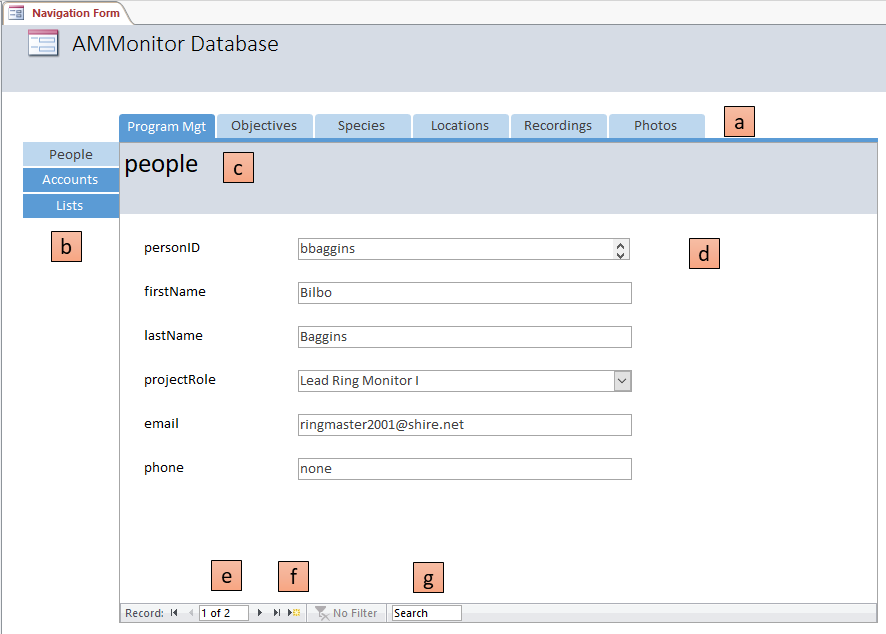

> *Figure 2.3. The AMMonitor Access front end is a navigation form, which is a collection of many different forms.*

Users may modify this form at will to meet the needs of their own monitoring program. Several online tutorials demonstrate how to edit and customize Microsoft Access forms to your liking. If you do not have Access, you may consider using the [Open Office Base](https://www.openoffice.org/product/base.html) program instead.

```r
# Save the Access form to your database directory
save(list = system.file("extdata", "AMMonitor_sqlite.accdb",
            package = "AMMonitor"),
     file = "database/Chap2_demo.accdb")
```

Hopefully, you now have the Access file in your **AMMonitor** database folder, recognizable by the “accdb” extension. Remember, this file is simply a collection of forms that can connect to a SQLite database, such as the “Chap2.sqlite” database that we have been working with. The next step is to actually make that connection.

## SQLite ODBC

To connect Access to our Chap2.sqlite database, we need a “driver”, which is a code snippet that will allow the SQLite database to connect to Microsoft Access. We will be using an ODBC driver, which stands for Open Database Connectivity. You can obtain the SQLite driver from http://www.ch-werner.de/sqliteodbc/. Make sure you select the appropriate driver for your machine’s operating system, and install it. As of this writing, we have been using the SQLite3 ODBC Driver on a machine running Windows 10 with no problems.

Download the driver for your machine and install it. Then follow these steps for Windows users (Mac users may need a different approach):

1. Navigate to your computer’s ODBC Data Source Administrator. You can likely search “ODBC” to find this on your machine, and it should look something like the below. Under the User DSN tab, click the Add button.

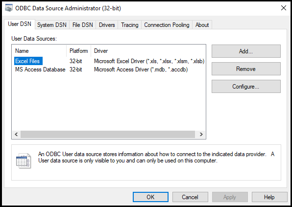

> *Figure 2.4. The ODBC Data Source Administrator dialogue box allows you to create new ODBC connections (Open Data Base Connectivity)*.
2. A new dialogue box will open, prompting you to select a driver. Locate the SQLite3 ODBC Driver you just installed, and click Finish.

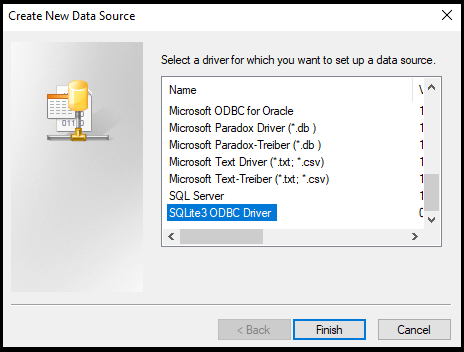

> *Figure 2.5. Select the SQLite3 ODBC Driver to let your computer communicate with the SQLite database*.
3. Another new dialogue box will open. You need to name your data source, navigate to a particular SQLite database, and press OK. Here, we are naming our data source Chap2_sqlite, and will connect to the sqlite database called chap2.sqlite using the Browse button. It is a good idea to have the data source name match up with the name of the database so that you can identify the database based on the data source name. Additionally, there are a few options that may be enforced, including a timeout entry (if there is database inactivity after a given period of time, the connection will automatically break). Other options for this dialogue box can be found [here](http://www.ch-werner.de/sqliteodbc/html/index.html).

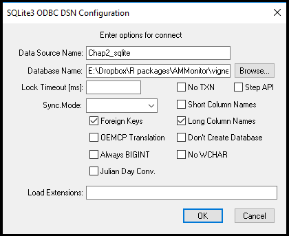

> *Figure 2.6. Give your connection a unique name, and browse to your SQLite database file.*
4. You should now see this new data source listed in the User DSN tab; it will allow you to connect to your SQLite database. You may have many data sources (e.g., one for each chapter if you wish). When it is time to launch your own monitoring program, however, the data source will connect to your program’s **AMMonitor** SQLite database.

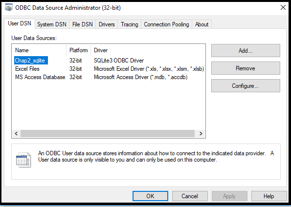

> *Figure 2.7. The new DNS should now be listed in your ODBC Data Source dialogue box.*

## Linking Access to the SQLite database

The next step is connect the Microsoft Access file to the SQLite database, employing the connection you just created. Here are the required steps.

1. Open the “Chap2_demo.accdb” file now stored in your **AMMonitor** database directory.
2. Click the External Data tab. This tab allows us to connect Access to an external database, such as an Excel file, another Access database, a text file or XML file. Here, we will use an ODBC connection, where ODBC stands for Open Database Connectivity.

[figure not shown]

> *Figure 2.8. Open Access, and click on the External Data tab.*
3. Clicking on the ODBC Database button will bring up a new dialogue box. Here, we want to **link** to the data source by creating a linked table. Press OK.

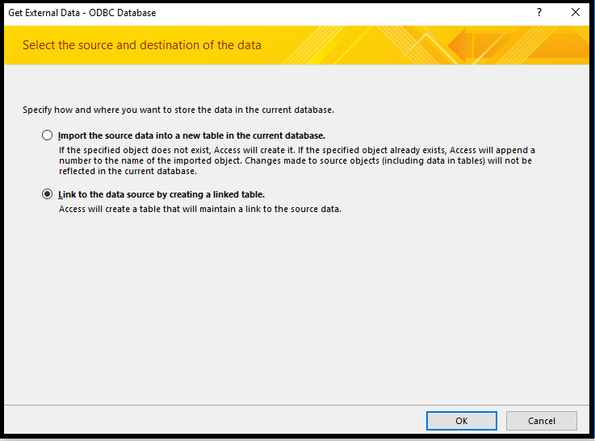

> *Figure 2.9. Indicate that you would like to link to the SQLite database (as opposed to importing the database into Access.*
4. Now, we wish to locate and use the data source we just created (which uses a SQLite3 driver to connect to our SQLite database). It will likely be listed under the Machine Data Source tab, and is highlighted in blue when clicked. Press OK.

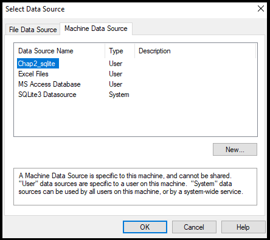

> *Figure 2.10. Locate your new database connection.*
5. The previous action will display a new dialogue box. This new box will ask which SQLite tables you wish to connect to. Press the Select All button to the right, which will highlight all of the tables in blue. Then press OK.

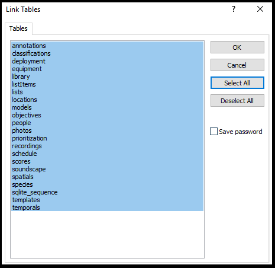

> *Figure 2.11. Press the Select All button to connect all the SQLite tables to Access.*
6. Under the “All Access Objects” left menu, you will see the tables. Each table has a globe symbol and arrow, indicating that each table is linked to the SQLite database table. This means we can now use Access to work with the data in our database tables.

[figure not shown]

> *Figure 2.12. The linked tables appear as “globes” in the left menu.*

Click on the **people** table, and you will see the two records currently in the SQLite database in a spreadsheet view:

[figure not shown]

> *Figure 2.13. You can work with tables in Access, but most tables will be filled in by R!*

A new record can be added by entering data into the row with the * symbol. Keep in mind, however, that many tables will be automatically populated by **AMMonitor** functions.

## Access Forms

Though you may work with tables directly as above, you can alternatively use the Navigation form introduced earlier in the chapter. Locate the Navigation form by collapsing the list of Tables (press the double arrow icon to the right of the word “Tables”), and opening the list of Forms.

[figure not shown]

> *Figure 2.14. The Access forms are diplayed in the left menu. The Navigation Form is the master form.*

Here, you can see that the **AMMonitor** front end comes with many individual forms that can be customized; these individual forms are combined into the Navigation Form. Opening the Navigation will bring you to the **AMMonitor** Navigation Form introduced earlier in the chapter.

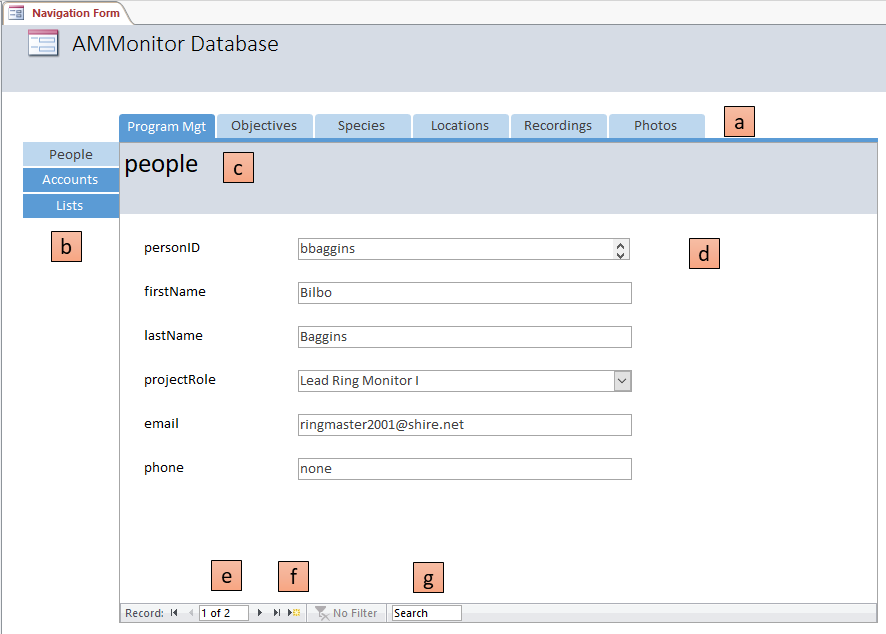

> *Figure 2.15. The AMMonitor Navigation Form. This form can be customized to your liking.*

The Navigation Form can be set as the default form that appears when the Access database is first opened. This can be achieved by going to File | Options | Current Database, and setting the Navigation Form as the Display Form. You may also add a customized title and icon here as well.

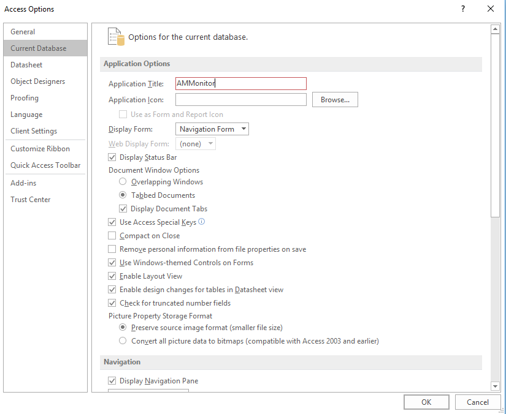

> *Figure 2.16. Force the Navigation Form to open when you open the Access file.*

# Chapter Summary

In the chapters that follow, we will create new, chapter-specific databases to illustrate each chapter’s key points. If your monitoring team adopts the **AMMonitor** framework, you will likely maintain a single database, and begin by establishing database standards that apply to your team. You can also modify the Access front-end to meet the needs of your monitoring effort.

# Bibliography

1. Müller K, Wickham H, James DA, Falcon S. RSQLite: ’SQLite’ interface for r (version 2.1,1) [Internet]. Comprehensive R Archive Network; 2018. Available: https://cran.r-project.org/web/packages/RSQLite/index.html

2. SQLite [Internet]. SQLite.org; 2018. Available: https://www.sqlite.org/index.html